# README

## Practical 2 Bonus Assignment: Lisa Martin

This is my work for Practical 2’s Bonus assignment

#### Loading required packages and data:

```r
#Seperate script used to load required packages
source("code/packageload.R")

# Loading required data
data <-
  read_rds("data/Fin_Data_SA_US_NKY.rds")

data <- na.omit(data)
```

#### Calculate the cap-weighted monthly index returns for every sector for each country:

I assumed that the formula to use for this is $Index_t = {Market Cap_t}/{Market Cap_{base}}$ In this case, I attempted to calculate a month on month return, therefore the base is the previous month for each period.However, this seemed to cause errors.

Upon consulting my peers, it seemed that I could first calulate the monthly returns and simply weight them by the market cap of each ticker in each sector.

```r
MonthlyReturns <-
  #Finding the last observation of each month for each ticker in each sector per country
  data %>%
  group_by(Universe, BICS_LEVEL_1_SECTOR_NAME, Ticker) %>%
  mutate(YM = format(date,"%Y_%B")) %>%
  ungroup() %>%
  group_by(Universe, BICS_LEVEL_1_SECTOR_NAME, YM) %>%
  filter(date == last(date)) %>%
  ungroup() %>%

  #Calculating the monthly return for each ticker, Remove the NA returns that would result during JAN
  group_by(Ticker) %>%
  arrange(date) %>%
  mutate(Returns = TRI/lag(TRI) - 1) %>%
  mutate(Returns = coalesce(Returns, 0)) %>%
  ungroup() %>%

  #Create weights for each ticker in terms of their contribution to total market cap
  group_by(Universe, BICS_LEVEL_1_SECTOR_NAME, YM) %>%
  mutate(SectorMarketCap = sum(Market.Cap)) %>%
  mutate(WeightedMarketCap = Market.Cap/SectorMarketCap) %>%

  #Calculating cap-weighted monthly returns by summing all of the weighted returns per sector
  mutate(WeightedReturns = sum(Returns*WeightedMarketCap)) %>%
  summarise(IndexReturn = mean(WeightedReturns)) %>%

  ungroup()
```

#### Calculate the sharpe ratio for the equally weighted by country, cap-weighted index returns since 2017:

```
MonthlyReturns_Sharpe <-
  MonthlyReturns  %>%
  group_by(Universe, BICS_LEVEL_1_SECTOR_NAME) %>%
  summarise(Sharpe = mean(MonthlyReturns, na.rm = TRUE) / sd(MonthlyReturns, na.rm = TRUE)) %>%
  ungroup()
```

This (above) method follows the Practical, however returns an error.

#### Plot all the cumulative returns for the Financials indexes of the three countries (whose Financials index outperformed?):

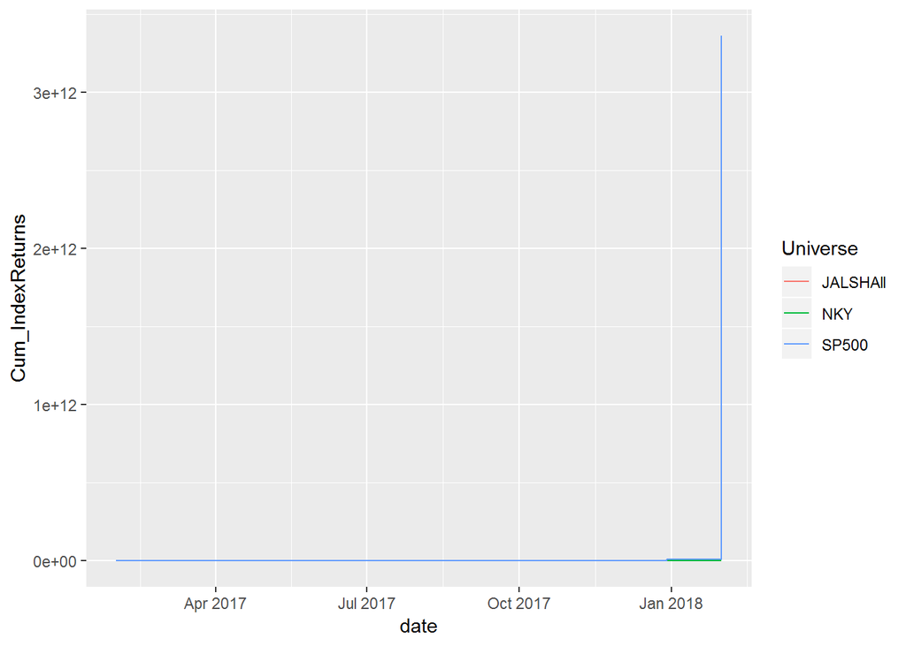

```r
Fin_Index_Returns <-
  #Finding the last observation of each month for each ticker in each sector per country
  data %>%
  group_by(Universe, BICS_LEVEL_1_SECTOR_NAME, Ticker) %>%
  mutate(YM = format(date,"%Y_%B")) %>%
  ungroup() %>%
  group_by(Universe, BICS_LEVEL_1_SECTOR_NAME, YM) %>%
  filter(date == last(date)) %>%
  ungroup() %>%

  #Calculating the monthly return for each ticker, Remove the NA returns that would result during JAN
  group_by(Ticker) %>%
  arrange(date) %>%
  mutate(Returns = TRI/lag(TRI) - 1) %>%
  mutate(Returns = coalesce(Returns, 0)) %>%
  ungroup() %>%

  #Create weights for each ticker in terms of their contribution to total market cap
  group_by(Universe, BICS_LEVEL_1_SECTOR_NAME, YM) %>%
  mutate(SectorMarketCap = sum(Market.Cap)) %>%
  mutate(WeightedMarketCap = Market.Cap/SectorMarketCap) %>%

  #Calculating cap-weighted monthly returns by summing all of the weighted returns per sector
  mutate(WeightedReturns = sum(Returns*WeightedMarketCap)) %>%
  ungroup() %>%

  #We need to filter the data to only focus on Financials
  group_by(BICS_LEVEL_1_SECTOR_NAME) %>%
  filter(BICS_LEVEL_1_SECTOR_NAME %in% "Financials") %>%

  #Next we can calculate cumulative returns per country
  group_by(Universe) %>%
  mutate(Cum_IndexReturns = cumprod(1 + WeightedReturns)) %>%
  ungroup()

  #Now we can plot the financial sectors cumulative returns
  ggplot(Fin_Index_Returns) +
  geom_line(aes(x = date, y = Cum_IndexReturns, color=Universe))
```

#### Calculate the JALSH index returns, by filtering the top 95% of Market Cap:

(Tip: use arrange and cumsum of weights. . . careful with your group_bys. . . )

```r
MonthlyReturns_JALSH <-
  #Finding the last observation of each month for each ticker in each sector per country
  data %>%
  group_by(Universe, BICS_LEVEL_1_SECTOR_NAME, Ticker) %>%
  mutate(YM = format(date,"%Y_%B")) %>%
  ungroup() %>%
  group_by(Universe, BICS_LEVEL_1_SECTOR_NAME, YM) %>%
  filter(date == last(date)) %>%
  ungroup() %>%

  #Calculating the monthly return for each ticker, Remove the NA returns that would result during JAN
  group_by(Ticker) %>%
  arrange(date) %>%
  mutate(Returns = TRI/lag(TRI) - 1) %>%
  mutate(Returns = coalesce(Returns, 0)) %>%
  ungroup() %>%

  #Create weights for each ticker in terms of their contribution to total market cap
  group_by(Universe, BICS_LEVEL_1_SECTOR_NAME, YM) %>%
  mutate(SectorMarketCap = sum(Market.Cap)) %>%
  mutate(WeightedMarketCap = Market.Cap/SectorMarketCap) %>%

  #We only want to do this for JALSH - remove other countries
  filter(Universe %in% "JALSHAll") %>%

  #Arrange the weights and find top 95%
  arrange(WeightedMarketCap) %>%
  mutate(CumWeight = cumsum(WeightedMarketCap)) %>%
  filter(CumWeight >= 0.05) %>%

  #Find the weighted returns for the top 95% of JALSH
  mutate(WeightedReturn = sum(Returns*WeightedMarketCap)) %>%
  summarise(JALSHReturn = mean(WeightedReturn)) %>%
  ungroup()
```

#### Calculate and visually compare the rolling 60 day standard deviation for the Materials sectors

of each country:

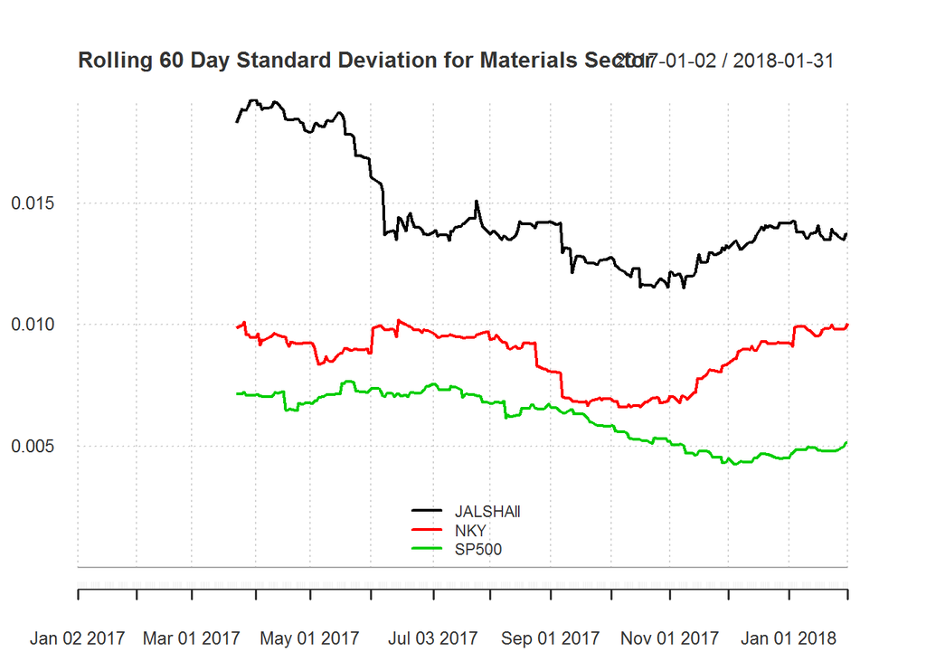

```r
Mat_IndexReturns <-
  #First we need to filter the data to only focus on Materials
  data %>%
  group_by(BICS_LEVEL_1_SECTOR_NAME) %>%
  filter(BICS_LEVEL_1_SECTOR_NAME %in% "Materials") %>%

  #Calculate the DAILY returns for each stock in the sector per country, Remove the NA returns that would result in the first period
  group_by(Ticker) %>%
  arrange(date) %>%
  mutate(Returns = TRI/lag(TRI) - 1) %>%
  mutate(Returns = coalesce(Returns, 0)) %>%
  ungroup() %>%

  #For each country, calculate the weighted retrun for the sector
  group_by(Universe, date) %>%
  mutate(SectorMarketCap = sum(Market.Cap)) %>%
  mutate(WeightedMarketCap = Market.Cap/SectorMarketCap) %>%
  mutate(WeightedReturns = sum(Returns*WeightedMarketCap)) %>%
  summarise(IndexReturn = mean(WeightedReturns)) %>%
  ungroup() %>%


  tbl_xts(., cols_to_xts = "IndexReturn", spread_by = "Universe")

  #Plot the rolling performance of the countries materials sectors using SD
  chart.RollingPerformance(R = Mat_IndexReturns, FUN = "sd",
      width = 60, main = "Rolling 60 Day Standard Deviation for Materials Sector",
      legend.loc = "bottom")
```